# CA chip 1

Chris, Charif, Charlotte, Julie

2025-04-16

Decide what chip you want to use.

Some IgEs that were equal to 9 were wrongly considered NAs.

Choose the factors of interest and convert them to factors.

```r
library(dplyr)
library(forcats)

# --- Define factors and label dictionaries ---
factors.of.interest <- c(
  "Région de France",
  "Type d'habitat",
  "Sexe",
  "Conjonctivite",
  "Syndrome oral",
  "Cofacteur_0",
  "Cofacteur_1",
  "Cofacteur_2",
  "Cofacteur_3",
  "Cofacteur_4",
  "Cofacteur_5",
  "Cofacteur_6",
  "Cofacteur_7",
  "Cofacteur_8",
  "Cofacteur_9",
  "Age"
)

region.france.dict <- c(
  "1" = "ARA",
  "2" = "BFC",
  "3" = "BRE",
  "4" = "CVL",
  "5" = "COR",
  "6" = "GES",
  "7" = "HDF",
  "8" = "IDF",
  "9" = "NOR",
  "10" = "NAQ",
  "11" = "OCC",
  "12" = "PDL",
  "13" = "PAC",
  "14" = "Outre"
)

sexe.dict <- c(
  "0" = "Female",
  "1" = "Male"
)

type.habitat.dict <- c(
  "0" = "Rural",
  "1" = "Urban"
)

# --- Define automatic age breaks and labels ---
age_breaks <- c(-1, 5, 10, 15, 20, 30, 40, 60, 100)
age_labels <- paste(
  age_breaks[-length(age_breaks)] + 1,
  age_breaks[-1],
  sep = "-"
)

chip.filtered <- chip %>%
  mutate(
    `Région de France` = factor(`Région de France`, levels = names(region.france.dict), labels = region.france.dict),
    Sexe = factor(Sexe, levels = names(sexe.dict), labels = sexe.dict),
    `Type d'habitat` = factor(`Type d'habitat`, levels = names(type.habitat.dict), labels = type.habitat.dict),
    Age = cut(
      as.numeric(as.character(Age)),
      breaks = age_breaks,
      labels = age_labels,
      right = TRUE,
      include.lowest = TRUE
    )
  ) %>%
  mutate(across(all_of(factors.of.interest), as.factor)) %>%
  select(all_of(factors.of.interest), all_of(cols_IgEs))
```

There is no NAs in the IgEs, but some/many in factors. We can impute them with mice-cart.

After preparing our chip, we perform a Correspondence Analysis on our dataset, with IgE variables as column variables of our contingency table and individual variables in the rows.

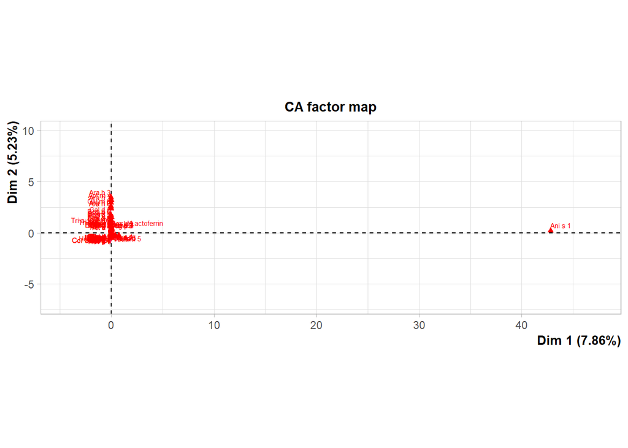

```r
quali.sup.cols <- match(factors.of.interest, colnames(chip.imputed))
res.ca <- FactoMineR::CA(chip.imputed, quali.sup = quali.sup.cols, graph=FALSE)

plot(res.ca, invisible = c("quali.sup", "row"), cex = 0.5)
```

### Ani s 1

The allergen Ani s 1 shows a very large value in the first CA component, while other column variables have close to 0 value. The same behaviour can be seen in the contributions of the column variable in the first dimension: “Ani s 1” contribution to first dimension is around 99.8, much larger than the other variables contributions, which are close to 0.

```r
res.ca$col$contrib[, 1]
```

```
##           Act d 1           Act d 2           Act d 5           Act d 8
##      1.168682e-04      1.962879e-05      2.922659e-06      1.352768e-04
##           Aln g 1           Alt a 1           Alt a 6           Amb a 1
##      8.388218e-04      1.038045e-03      8.567522e-05      1.364721e-04
##           Ana o 2           Ani s 1           Ani s 3           Api g 1
##      1.025102e-04      9.981171e+01      7.933081e-04      2.011554e-04
##           Api m 1           Api m 4           Ara h 1           Ara h 2
##      2.280109e-06      3.325514e-06      2.175412e-03      3.348651e-03
##           Ara h 3           Ara h 6           Ara h 8           Ara h 9
##      1.454158e-03      2.990352e-03      5.692084e-04      1.628271e-04
##           Art v 1           Art v 3           Asp f 1           Asp f 3
##      7.361181e-02      3.868234e-05      2.721011e-06      9.242451e-05
##           Asp f 6           Ber e 1           Bet v 1           Bet v 2
##      3.724109e-05      3.996124e-06      2.792467e-03      3.221984e-04
##           Bet v 4           Bla g 1           Bla g 2           Bla g 5
##      3.343237e-04      8.122828e-06      2.288511e-05      3.123257e-05
##           Bla g 7           Blo t 5           Bos d 4           Bos d 5
##      7.309493e-04      3.900123e-04      7.198049e-04      5.008751e-04
##           Bos d 6           Bos d 8 Bos d Lactoferrin           Can f 1
##      2.887227e-04      5.586544e-04      8.511247e-10      1.390137e-03
##           Can f 2           Can f 3           Can f 5           Che a 1
##      5.890223e-04      2.068548e-04      3.765972e-04      9.995386e-05
##           Cla h 8      Cor a 1.0101      Cor a 1.0401           Cor a 8
##      6.531786e-06      7.826840e-04      9.974960e-04      5.355106e-05
##           Cor a 9           Cry j 1           Cup a 1           Cyn d 1
##      1.253232e-04      2.786726e-07      2.162137e-04      1.280947e-03
##           Der f 1           Der f 2           Der p 1          Der p 10
##      2.867057e-03      5.046368e-03      3.027830e-03      5.416190e-04
##           Der p 2           Equ c 1           Equ c 3           Fag e 2
##      3.904930e-03      5.741005e-04      8.343661e-05      7.027659e-07
##           Fel d 1           Fel d 2           Fel d 4           Gad c 1
##      1.301071e-03      2.349484e-04      8.532197e-04      2.925837e-04
##           Gal d 1           Gal d 2           Gal d 3           Gal d 5
##      6.747799e-04      2.852108e-04      9.209130e-05      1.635639e-04
##           Gly m 4           Gly m 5           Gly m 6           Hev b 1
##      4.323114e-04      1.593414e-04      6.814901e-04      3.290151e-05
##           Hev b 3           Hev b 5        Hev b 6.01           Hev b 8
##      2.768068e-05      3.006303e-05      3.984303e-05      4.555583e-04
##           Jug r 1           Jug r 2           Jug r 3           Lep d 2
##      2.941378e-04      2.998600e-05      3.884007e-04      7.935078e-04
##           Mal d 1           Mer a 1           Mus m 1             MUXF3
##      1.531463e-03      4.152404e-04      5.490115e-04      4.510600e-05
##           Ole e 1           Ole e 7           Ole e 9           Par j 2
##      1.778963e-06      1.151176e-06      8.177213e-05      1.067143e-05
##           Pen m 1           Pen m 2           Pen m 4           Phl p 1
##      8.861960e-04      4.120845e-04      2.058129e-04      1.955389e-03
##          Phl p 11          Phl p 12           Phl p 2           Phl p 4
##      5.575548e-04      1.013368e-04      9.051487e-04      7.431161e-05
##           Phl p 5           Phl p 6           Phl p 7           Pla a 1
##      2.243481e-03      4.678240e-04      3.436580e-04      7.333044e-04
##           Pla a 2           Pla a 3           Pla l 1           Pol d 5
##      7.427169e-03      1.560830e-04      7.994477e-04      6.897739e-03
##           Pru p 1           Pru p 3           Sal k 1           Ses i 1
##      1.041852e-03      3.712237e-04      5.005415e-08      5.966855e-05
##          Tri a 14     Tri a 19.0101       Tri a aA_TI           Ves v 5
##      6.588054e-05      3.148427e-05      3.049151e-05      3.579097e-02
```

This means that “Ani s 1” alone contributes in explaining a large percentage of the variance, and its contribution is due to a specific subset of samples, which have high value in “Ani s 1” but close to 0 value in the other IgEs.

By looking at the data, we notice that observation 85 has value 101.48 in “Ani s 1” and close or equal to 0 values in the other IgE variables. If we remove it and recompute the CA, we have

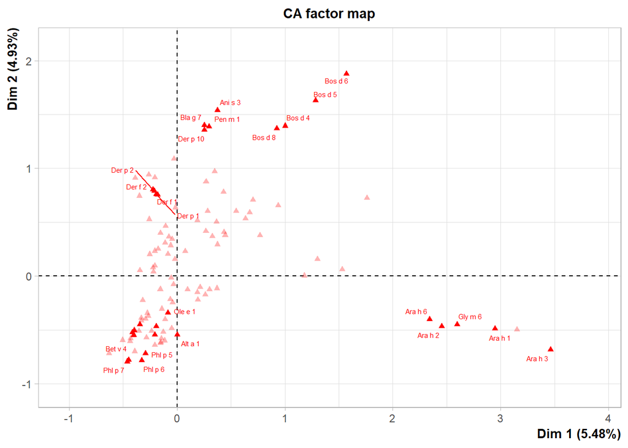

```r
chip.imputed.no85 <- chip.imputed[-85,]
res.ca.no85 <- FactoMineR::CA(chip.imputed.no85, quali.sup = quali.sup.cols, graph=FALSE)
plot(res.ca.no85, invisible = c("quali.sup", "row"), cex = 0.5, selectCol = "contrib 30") # if option selectCol = "contrib 30" is removed, it is possible to find "Ani s 1" in the bottom left
```

Note: We notice that if we consider the second and third dimensions of the CA with the original dataset, we find the same plot:

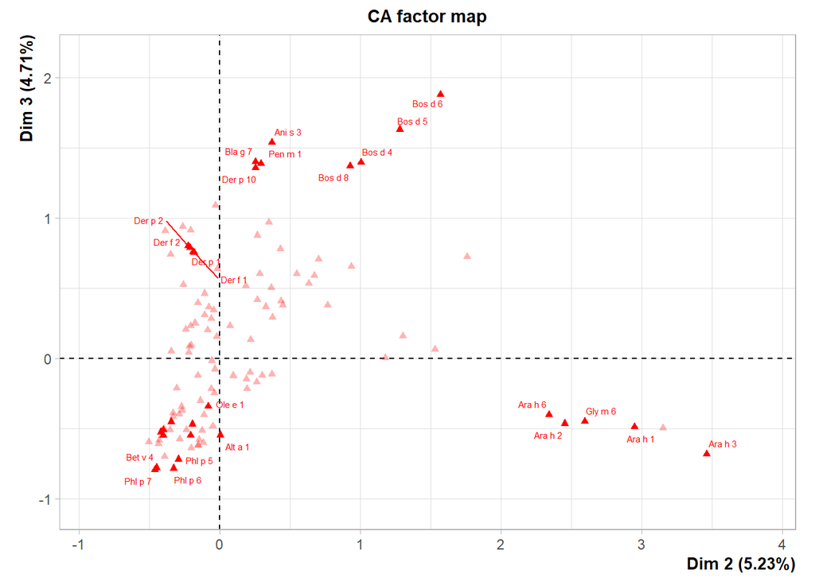

```r
plot(res.ca, axes=c(2,3), invisible = c("quali.sup", "row"), cex = 0.5, selectCol = "contrib 30")
```

Therefore observation 85 was creating some signal that made “Ani s 1” be suggested as a key factor separating our samples. This note confirms our previous findings and supports our choice of removing observation 85.

The projection of the first two dimensions reveals the presence of two distinct allergen clusters. A (more evident) cluster of “Ara h 1”, “Ara h 2”, “Ara h 3”, “Ara h 6”, “Gly m 6” and “Api m 4” (the last one has low contribution on the variance explained by two dimensions). This suggests that individuals tend to have similar patterns in the occurrence of these IgEs. A secondary cluster is formed by “Bos d 4”, “Bos d 5”, “Bos d 6” and “Bos d 8”.

We then plot dimensions 3 and 4:

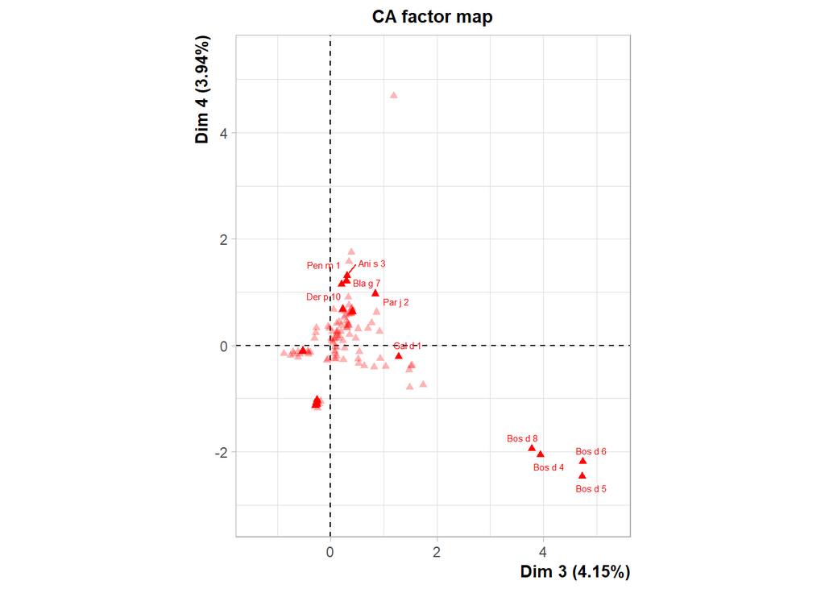

```r
plot(res.ca.no85, axes = c(3,4), invisible = c("quali.sup", "row"), cex = 0.5, selectCol = "contrib 20") # here if we remove selectCol = "contrib 30" we find that the point on the top (with Dim 4 around 4.7) is "Ani s 1"
```

Third and fourth dimensions show more clearly the cluster formed by “Bos d 4”, “Bos d 5”, “Bos d 6” and “Bos d 8”.

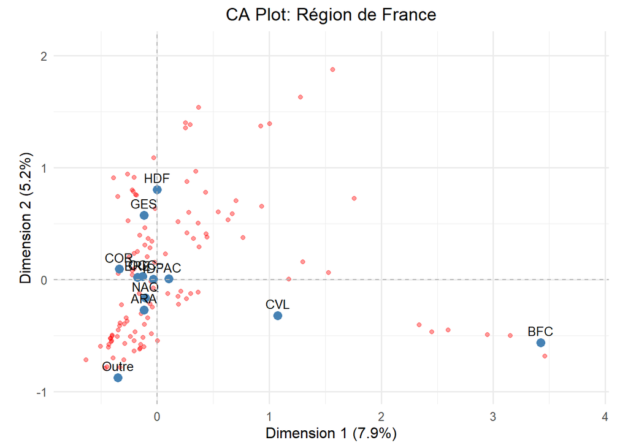

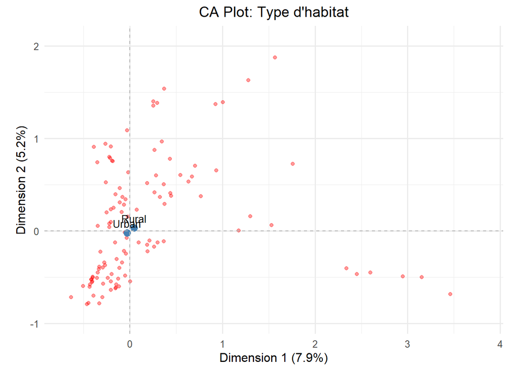

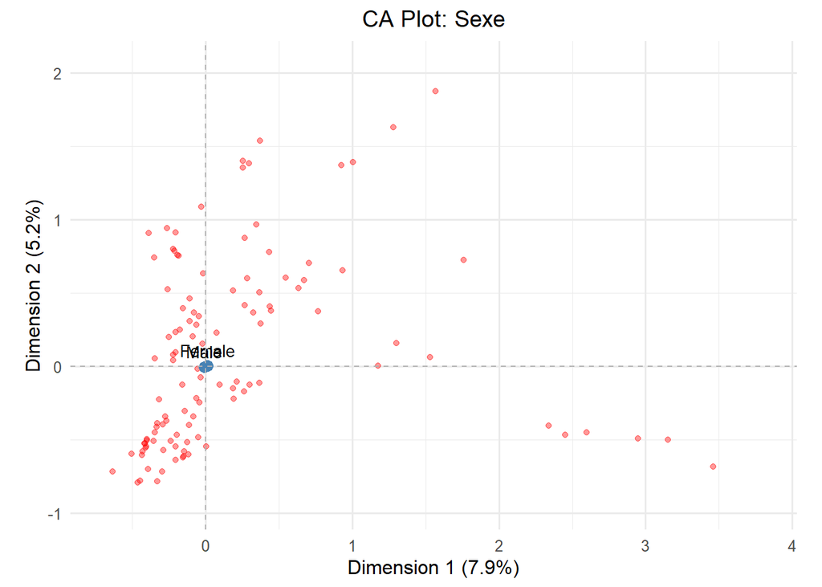

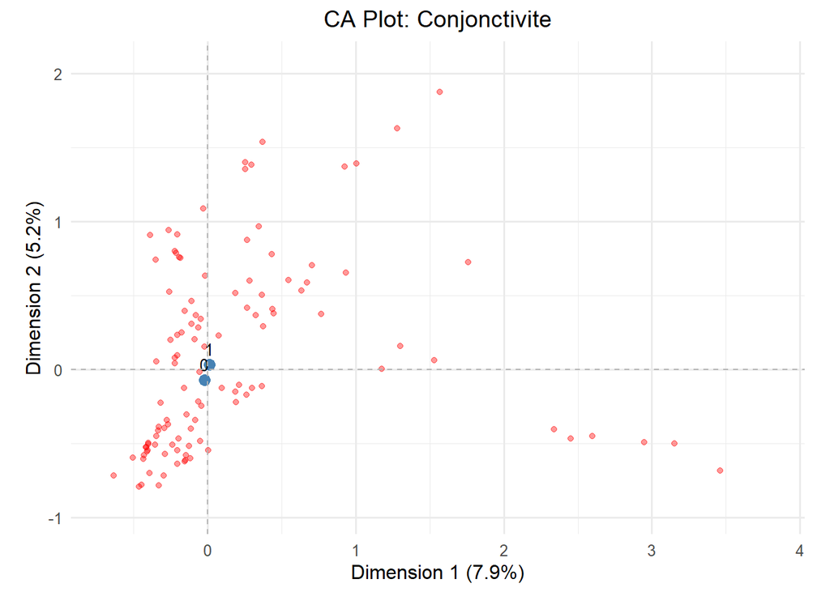

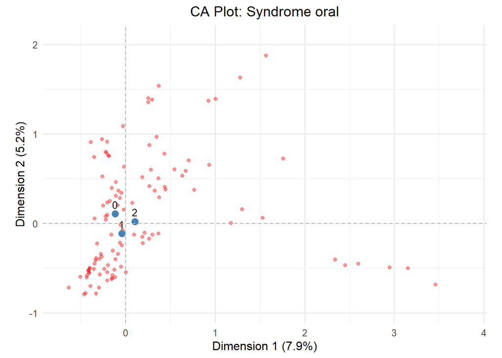

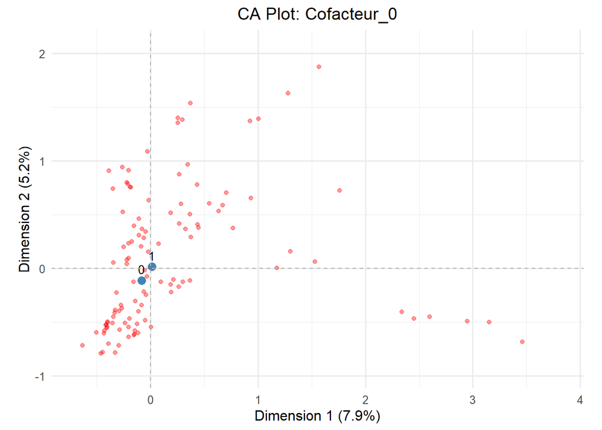

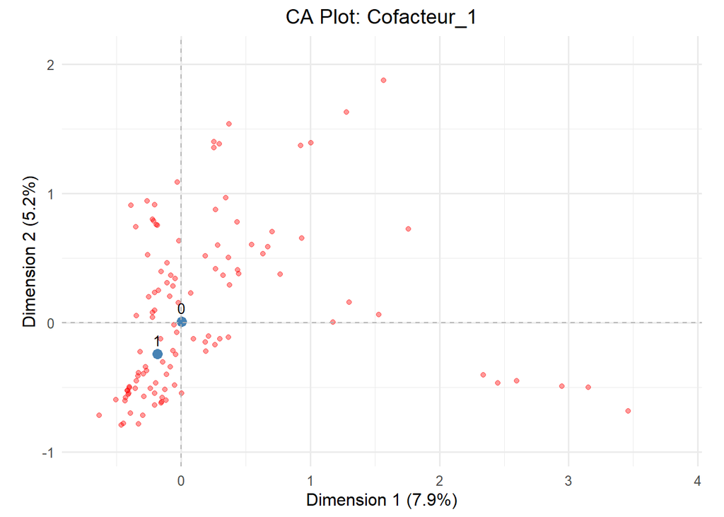

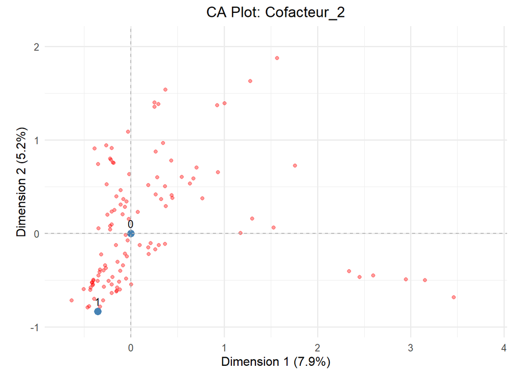

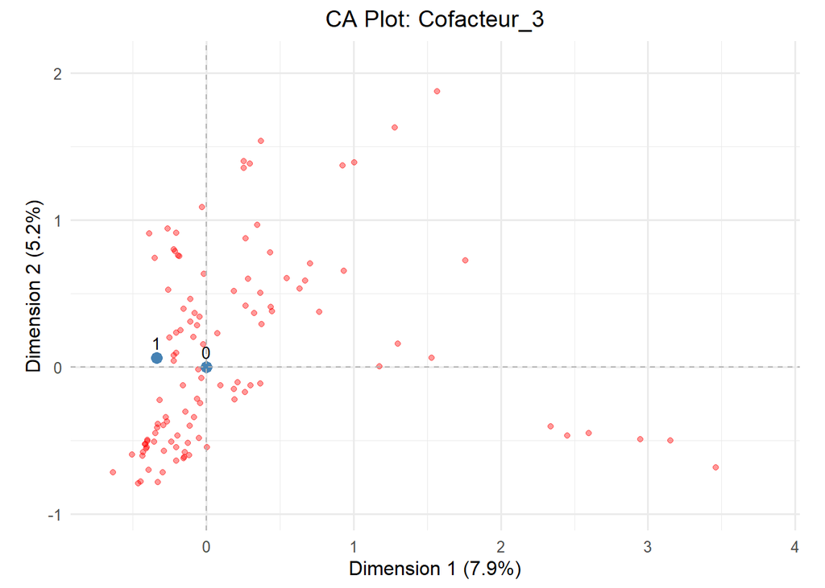

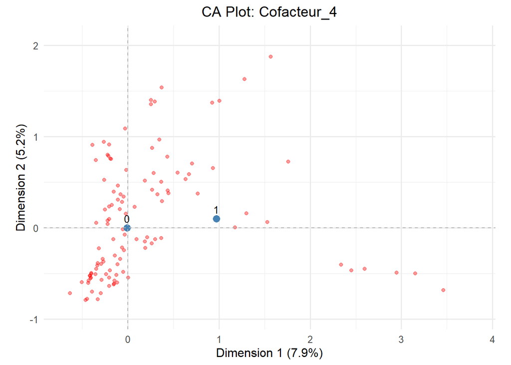

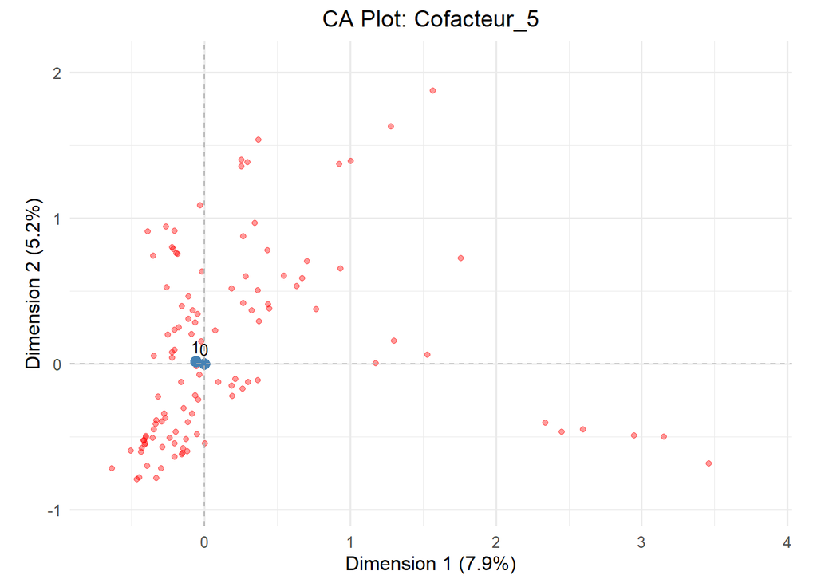

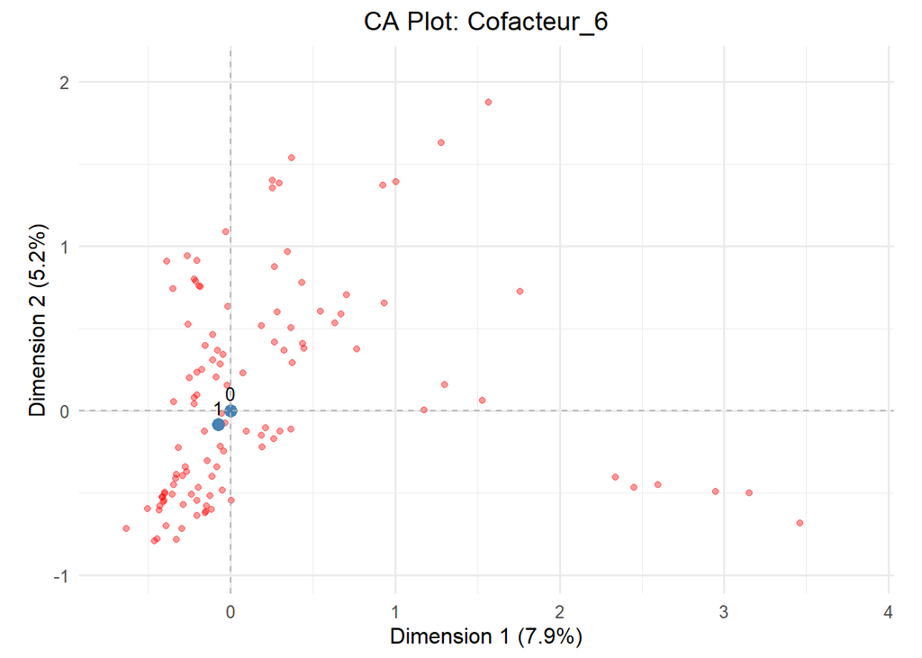

[4 more figures not shown]

```r
library(ggplot2)
library(stringr)

coords.factors <- res.ca.no85$quali.sup$coord[,1:2]
coords.cols <- res.ca.no85$col$coord[,1:2]

coords.cols.df <- data.frame(
  Dim1 = coords.cols[, 1],
  Dim2 = coords.cols[, 2],
  Label = rownames(coords.cols) # Keep labels handy if you want to add them later
)

axis_label_dim1 <- paste0("Dimension 1 (", round(res.ca$eig[1,2], 1), "%)")
axis_label_dim2 <- paste0("Dimension 2 (", round(res.ca$eig[2,2], 1), "%)")

x_limits <- range(c(coords.factors[,1], coords.cols[,1])) * 1.1 # Add some padding
y_limits <- range(c(coords.factors[,2], coords.cols[,2])) * 1.1 # Add some padding

for (fac in factors.of.interest){

  matching_rows <- coords.factors[startsWith(rownames(coords.factors), paste0(fac, ".")), ]

  levels <- str_remove(rownames(matching_rows), paste0(fac, "\\."))

  temp <- data.frame(
    Dim1 = matching_rows[, 1],
    Dim2 = matching_rows[, 2],
    Level = levels
  )

  p <- ggplot(temp, aes(x = Dim1, y = Dim2, label = Level)) + # Base plot using factor levels

    geom_point(data = coords.cols.df, aes(x = Dim1, y = Dim2), # Specify data and aesthetics
               color = "red", size = 1.5, alpha = 0.4, inherit.aes = FALSE) +
    geom_point(color = "steelblue", size = 3) +
    geom_text(vjust = -0.7, hjust = 0.5, size = 3.5) +
    labs(title = paste("CA Plot:", fac),
         x = axis_label_dim1, y = axis_label_dim2) +
    theme_minimal(base_size = 12) +
    theme(plot.title = element_text(hjust = 0.5)) +
    xlim(x_limits) +
    ylim(y_limits) +
    coord_fixed() +
    geom_hline(yintercept = 0, linetype="dashed", color = "grey70") +
    geom_vline(xintercept = 0, linetype="dashed", color = "grey70")

  print(p)
}
```

When projecting the dimensions onto the regional space, we observe that the region Bourgogne-Franche-Comté (BFC) presents a high prevalence of individuals with non-zero values of IgEs “Ara h 1”, “Ara h 2”, “Ara h 3”, “Ara h 6”, “Gly m 6” and “Api m 4”. On the other hand, IgEs “Bos d 4”, “Bos d 5”, “Bos d 6” and “Bos d 8” do not exhibit any distinct regional predominance.